# Reproducible_Research_Project_Week 2

## Peer-graded Assignment: Course Project 1

Downloading data from a local folder “…Coursera_R/Reproducible_Research” Also echoing (showing all code) with echo = TRUE

```r
knitr::opts_chunk$set(echo = TRUE)
my_folder <- "C:/Users/thejt/Desktop/MOOC/Coursera_R/Reproducible_Research/"
activity <- read.csv(paste(my_folder,"activity.csv", sep = ""))
```

Determining if a day in the data set is a weekend or a weekday

```r
activity$dayofWeek  <- weekdays(as.Date(activity$date))
activity$weekend    <- as.POSIXlt(activity$date)$wday == "0" | as.POSIXlt(activity$date)$wday == "6"
```

Counting the steps per day and creating a histogram

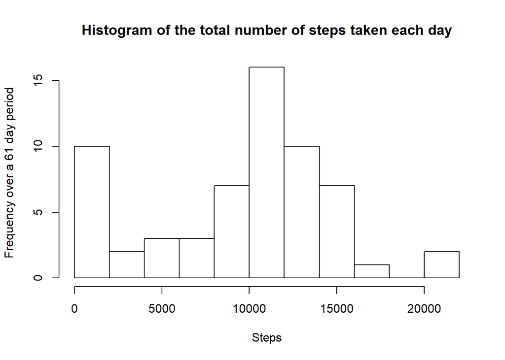

```r
stepsperDay         <- aggregate(activity$steps, by = list(activity$date), sum, na.rm = TRUE )
hist(stepsperDay$x, main = "Histogram of the total number of steps taken each day",
     xlab = "Steps", ylab = "Frequency over a 61 day period", breaks = 15)
```

The mean and median number of steps taken is shown here:

```r
stepsbyDate         <- aggregate(activity$steps, by = list(activity$date), sum,    na.rm = TRUE)
meanSteps           <- mean(stepsbyDate$x, na.rm = TRUE)
medianSteps         <- median(stepsbyDate$x, na.rm = TRUE)
```

The mean and median number of steps are: 9354.2295082 & 10395

The average number of steps taken per week is shown here:

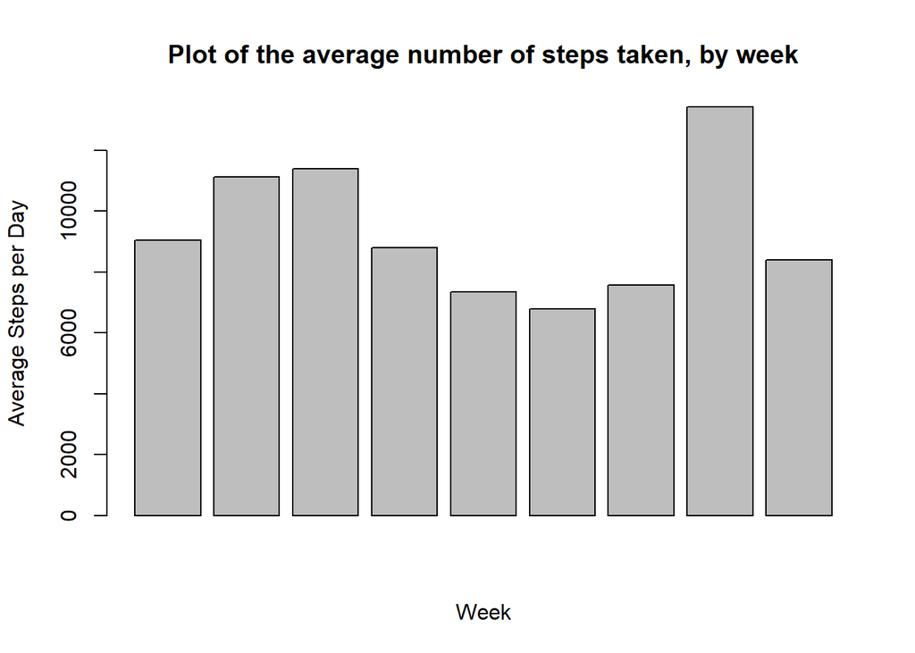

```r
stepsbyDate$weekofyear    <- strftime((stepsbyDate$Group.1), format = "%V")
stepsbyweekNum      <- aggregate(stepsbyDate$x, by = list(stepsbyDate$weekofyear), mean, na.rm = TRUE)
barplot(height = stepsbyweekNum$x, width = 1, ylab = "Average Steps per Day", xlab = "Week",
        main = "Plot of the average number of steps taken, by week")
```

Let’s look for the 5 minute interval that averages the maximim number of steps

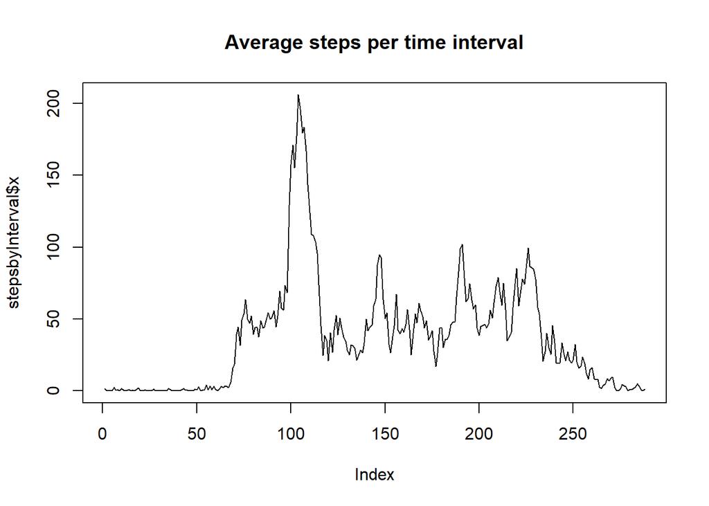

```r
stepsbyInterval <- aggregate(activity$steps, by = list(activity$interval), mean, na.rm = TRUE)
max.value = max(stepsbyInterval$x)
plot(stepsbyInterval$x, type = "l", main = "Average steps per time interval")
```

```r
max.intervalue <- stepsbyInterval$Group.1[stepsbyInterval$x==max(stepsbyInterval$x)]
```

The maximum value of the above chart is 206.1698113 and belongs to the interval of name 835

Now we need to impute the missing values where the value NA appears in the steps column. I am going to use the existing mean for the time interval to patch the data frame.

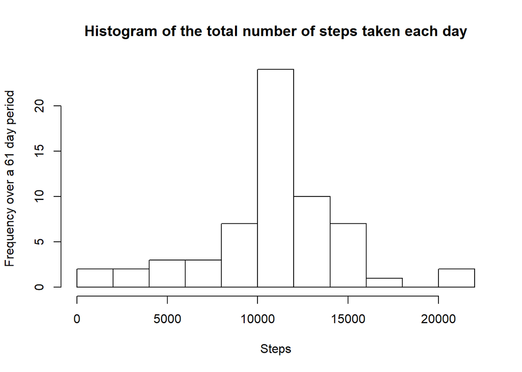

```r
activity$steps[is.na(activity$steps)]<-stepsbyInterval$x
stepsperDayclean         <- aggregate(activity$steps, by = list(activity$date), sum, na.rm = TRUE )
hist(stepsperDayclean$x, main = "Histogram of the total number of steps taken each day",
     xlab = "Steps", ylab = "Frequency over a 61 day period", breaks = 15)
```

The histogram for steps per day looks better. On the left hand side of the chart, there are not as many values attributed to the first bar where the NAs would normally show.

Now we can compare weekends and weekdays

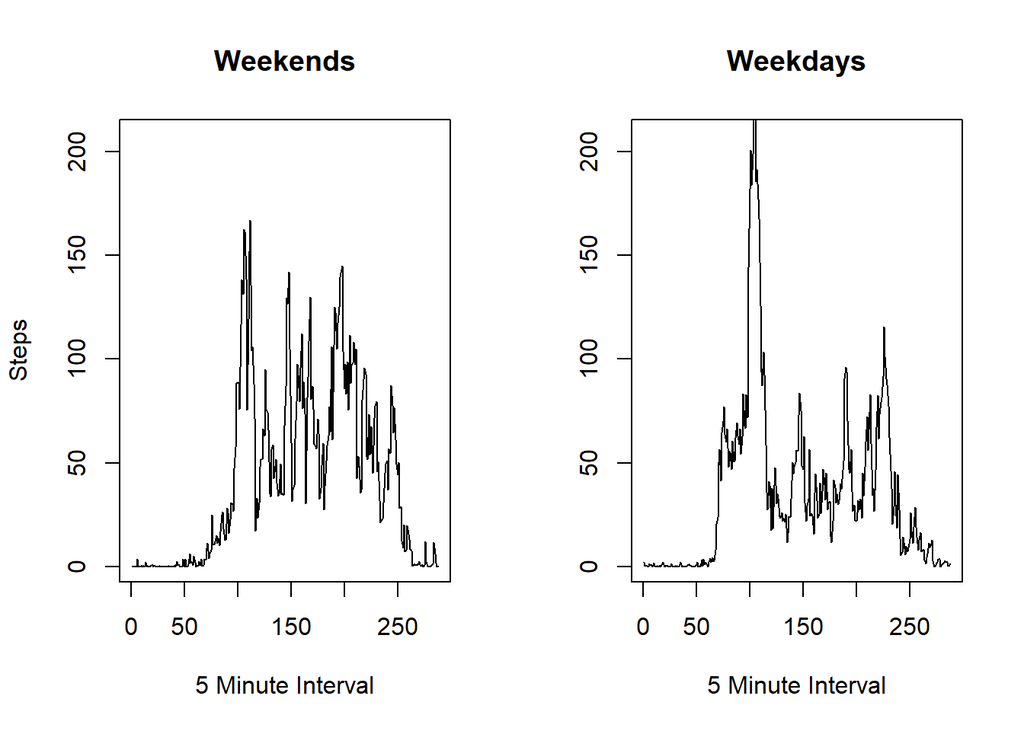

```r
stepsWeekend <- subset(activity, weekend == TRUE)
stepsWeekday <- subset(activity, weekend == FALSE)

weekendstepsbyInterval <- aggregate(stepsWeekend$steps, by = list(stepsWeekend$interval), mean, na.rm = TRUE)
weekdaystepsbyInterval <- aggregate(stepsWeekday$steps, by = list(stepsWeekday$interval), mean, na.rm = TRUE)

par(mfrow = c(1,2))
plot(weekendstepsbyInterval$x, type = "l", main = "Weekends",
     ylab = "Steps", xlab = "5 Minute Interval", ylim = c(1,207))
plot(weekdaystepsbyInterval$x, type = "l", main = "Weekdays",
      ylab = "", xlab = "5 Minute Interval", ylim = c(1,207))
```

We can see that the weekdays have a “usual time” where lots of steps are occuring. This is probably a commute to a job or could be daily exercise. The weekends involve more steps and likely less sitting at a desk.